# Heart Failure Inpatient Analysis

Harrison Nguyen and Charmaine Tam

10/11/2021

```r
library(magrittr)
library(targets)
library(tidyverse)
library(kableExtra)
library(ggplot2)
library(ggpubr)
library(acs)
library(flextable)

library(hefd)
```

```r
proportion_bar_plot <- function(df,column,title,n_suffix = NULL,vjust=-0.25){
  if(is.null(n_suffix)){
    title <- paste0(title, " (N = ",nrow(df), ")")
  }
  else{
    title <- paste0(title, " (N = ",nrow(df), " ",n_suffix, ")")
  }

  plot<- df %>%
     ggplot2::ggplot(., aes(x=!!rlang::sym(column),fill=!!rlang::sym(column))) +
    ggplot2::geom_bar(aes(y = ..count..),stat="count",alpha=0.5,show.legend = FALSE) +
    ggplot2::xlab(title) +
    ggplot2::ylab("Count") +
    ggtitle(title) +
    geom_text(
       aes(label=paste(round((..count..)/sum(..count..)*100,0),"%",sep=""),y= ..count..),
       stat='count',
       vjust=vjust
   ) +
  theme_minimal()


  return(plot)
}

conditional_bar_plot <- function(df,var1,var2,title,n_suffix = NULL){
  if(is.null(n_suffix)){
    title <- paste0(title, " (N = ",nrow(df), ")")
  }
  else{
    title <- paste0(title, " (N = ",nrow(df), " ",n_suffix, ")")
  }

  var1<- rlang::sym(var1)
  var2<- rlang::sym(var2)
  plot <- df%>%
  dplyr::count(!!var1,!!var2) %>%
  dplyr::group_by(!!var1) %>%
  dplyr::mutate(prop = prop.table(n)*100) %>%
  ggplot2::ggplot(., aes(x=!!var1,y=n,fill=!!var2)) +
  geom_bar(stat="identity",position=position_dodge(0.7),width=0.7,alpha=0.5) +
  geom_text(aes(label= paste(round(prop,0),"%",sep=""),y=n),position=position_dodge(0.7),vjust=-0.5) +
  labs(y="Count",x=var1, title = title) +
  scale_fill_discrete(name = var2) +
  theme_minimal()

  return(plot)
}

plot_histogram <- function(df,column, title,threshold = NULL,n_suffix=NULL){
  if(is.null(n_suffix)){
    title <- paste0(title, " (N = ",nrow(df), ")")
  }
  else{
    title <- paste0(title, " (N = ",nrow(df), " ",n_suffix, ")")
  }

  var1<- rlang::sym(column)

  df %<>% dplyr::filter(!is.na(!!var1))


  plot <- df %>%
  ggplot2::ggplot(., aes(x=!!var1,fill=!!var1)) +
   geom_histogram(fill="lightblue",alpha=0.5) +
  labs(y="Count",x=var1, title = title)+
    scale_x_continuous(breaks = scales::pretty_breaks(n = 10))+
    stat_bin(aes(y=..count.., label=ifelse(..count..==0,"",..count..)), geom="text", vjust=-.5) +
  theme_minimal()



  if(!is.null(threshold)){
    plot <- plot + geom_vline(aes(xintercept=threshold),
            color="red", linetype="dashed", size=1)
  }

  return(plot)
}

plot_histogram_group <- function(df,var1,var2,title,n_suffix){

  if(is.null(n_suffix)){
    title <- paste0(title, " (N = ",nrow(df), ")")
  }
  else{
    title <- paste0(title, " (N = ",nrow(df), " ",n_suffix, ")")
  }

  var1<- rlang::sym(var1)
  var2<- rlang::sym(var2)

  df %<>% dplyr::filter(!is.na(!!var1)) %>%
    dplyr::filter(!is.na(!!var2))


  plot <- df %>%
  ggplot2::ggplot(., aes(x=!!var1,fill=!!var2,color=!!var2)) +
   geom_histogram(aes(y=..density..),alpha=0.5, position="identity") +
    geom_density(alpha=0.3)+
  labs(y="Count",x=var1, title = title)+
    scale_x_continuous(breaks = scales::pretty_breaks(n = 10))+
  theme_minimal()


  return(plot)
}

plot_logical_columns <- function(df,var1,title,n_suffix=NULL,vjust=-0.5){
  if(is.null(n_suffix)){
    title <- paste0(title, " (N = ",nrow(df), ")")
  }
  else{
    title <- paste0(title, " (N = ",nrow(df), " ",n_suffix, ")")
  }

  var1<- rlang::sym(var1)

  plot_data <- df %>%
    dplyr::summarise_if(is.logical,sum) %>%
   tidyr::pivot_longer(everything(),values_to = "N",names_to = rlang::as_string(var1)) %>%
  dplyr::mutate(prop = N/nrow(df)*100)

  plot <- plot_data %>%
       ggplot2::ggplot(., aes(x=!!var1,y=N,fill=!!var1)) +
      ggplot2::geom_bar(position="dodge", stat="identity",show.legend = FALSE) +
    geom_text(aes(label= paste(round(prop,0),"%",sep=""),y=N),vjust=vjust) +
    labs(y="Count",x=var1, title = title)

  return(plot)
}
```

```r
plot_pie_chart <- function(df,var1,title,n_suffix = NULL){
  if(is.null(n_suffix)){
    title <- paste0(title, " (N = ",nrow(df), ")")
  }
  else{
    title <- paste0(title, " (N = ",nrow(df), " ",n_suffix, ")")
  }

  var1<- rlang::sym(var1)
  df %<>%
    filter(!is.na(!!var1)) %>%
    group_by(!!var1) %>% # Variable to be transformed
    count() %>%
    ungroup() %>%
    mutate(perc = `n` / sum(`n`)) %>%
    arrange(perc) %>%
    mutate(labels = scales::percent(perc))

  plot <- ggplot(df, aes(x = "", y = n, fill = !!var1)) +
    geom_col() +
    geom_text(aes(label = labels),
              position = position_stack(vjust = 0.5)) +
    coord_polar(theta = "y")
    labs(y="Count",x=var1, title = title)

  return(plot)
}
```

```r
encounter_ref <- load_data("encounter_reference")
encounter <- load_data("encounter")
diagnosis <- load_data("diagnosis")
diagnosis_history <- load_data("diagnosis_history")
problem <- load_data("problem")
orders <- load_data("orders")
patient <- load_data("patient")
```

```r
query <- glue::glue("SELECT * from MEDICATION_ORDERS as x \\
            WHERE ENCNTR_ID in (SELECT PX9_ENCNTR_ID from ENCOUNTER_REFERENCE \\
             WHERE Q4_DIAGNOSIS = 1 and PROCESS_FLAG = 1 and HISTORY_FLAG = 0) and (ORIG_ORD_AS_FLAG = 1 OR ORIG_ORD_AS_FLAG=2)")
medication_order <- execute_query(query)

hf_form <- execute_query("SELECT * from DCP_FORMS_ACTIVITY where DESCRIPTION = 'Heart Failure (MACARF) Referral Form' or DESCRIPTION = 'Heart Failure - Management of Cardiac Function Enrolment'")
```

```r
location_string <- "Royal North Shore"
hf_diag <- diagnosis %>%
  dplyr::filter(stringr::str_detect(SOURCE_IDENTIFIER,"(?i)I50") & DIAG_TYPE_CD == "Final")

qual_enc <- encounter %>%
  dplyr::filter(ENCNTR_ID %in% hf_diag$ENCNTR_ID & LOC_FACILITY_CD == location_string)

cohort <- qual_enc %>%
  dplyr::distinct(PERSON_ID)

time_period <- round(difftime(max(qual_enc$DISCH_DT_TM,na.rm = TRUE), min(qual_enc$DISCH_DT_TM,na.rm = TRUE),units="days")/362.2425,1)
```

#### 0.0.0.1 Change log

- 15/10/2021
  - added comparison of ACD with age
  - split historical diagnoses into primary and secondary
  - added figure of forms over time
  - added plot of `ferric carboxymaltose` against LOS

# 1 Introduction

This document will investigate encounters that have been coded with a heart failure-related ICD10 code (I50; primary or secondary) at **Royal North Shore** Hospital with discharge dates between **2019-01-01** to **2021-07-31**. Thus, in a **2.6** year period, there are **3538** encounters with unique **2654** patients. Figure 1.1 shows the distribution of the number of encounters for each patient and Figure 1.2 shows the distribution of encounters type where the majority of encounters are **inpatient** encounters.

The analysis of this cohort will be used to examine:

1. Demographics and characteristics
- Total admissions by facility
- Age and sex distributions
- Numbers of patient journeys and transfers across the District
- Mode of admission and mode of separation
- Number of patients with Advanced Care Directive
- Previous hospitalisation in the past 3 years (for HF or other?, primary or additional diagnoses?)
2. Investigations
- Number of patients with at least 1 echocardiogram performed
- BNP and Iron profiles
3. Discharge management
- Number of patients with discharge letters
- Number of patients on relevant discharge medications or none
- Number of patients that are referred to the HF service

This feasibility analyses will be initially be performed for encounters at RNSH, then Ryde and Hornsby, and then patients that transfer between NSLHD facilities.

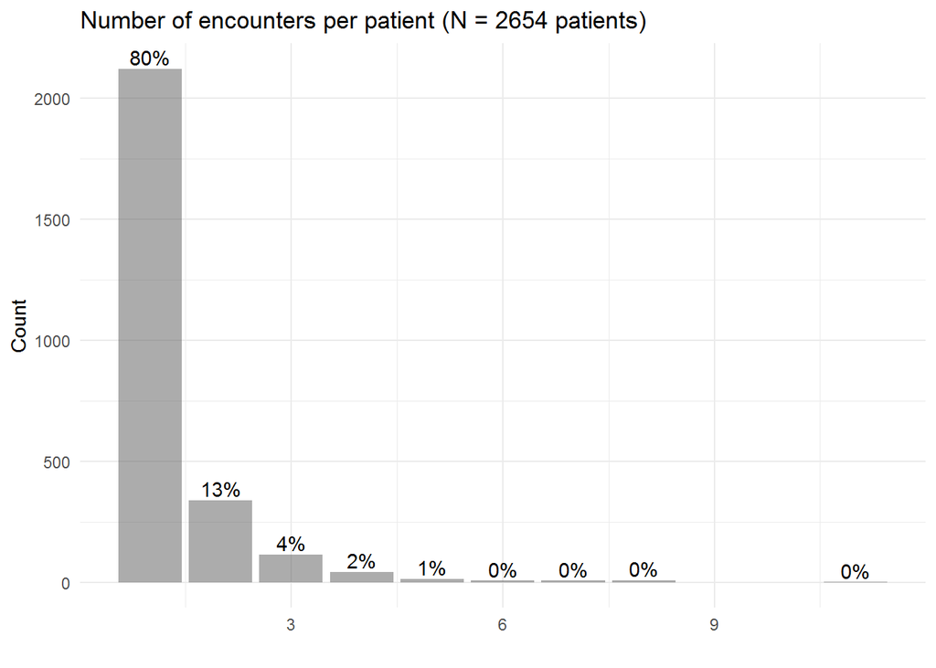

Figure 1.1: Distribution of the number of encounters for each patient.

```r
counts <- qual_enc %>%
  dplyr::group_by(PERSON_ID) %>%
  dplyr::summarise(N = dplyr::n())

proportion_bar_plot(counts,"N", "Number of encounters per patient",n_suffix="patients") + xlab("")
```

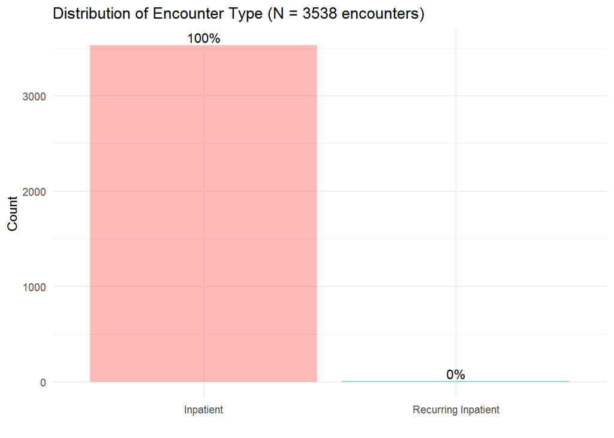

Figure 1.2: Distribution of Encounter Type.

```r
proportion_bar_plot(qual_enc,"ENCNTR_TYPE_CD","Distribution of Encounter Type",n_suffix = "encounters") + xlab("")
```

```r
extract_hf_diagnosis <- function(df,group_cols = "ENCNTR_ID",split_priority = FALSE){

  group_cols <- rlang::sym(group_cols)

  if(!split_priority){
     df %<>%
      dplyr::group_by(!!group_cols) %>%
      dplyr::summarise(
        `Congestive heart failure` = any(SOURCE_IDENTIFIER == "I50.0" | SOURCE_IDENTIFIER == "I50"),
        `Heart failure, unspecified` = any(SOURCE_IDENTIFIER == "I50.9"),
        `Left ventricular failure` = any(SOURCE_IDENTIFIER == "I50.1")
      ) %>%
      replace(is.na(.), FALSE)
  }
  else{
     df %<>%
      dplyr::group_by(!!group_cols) %>%
      dplyr::summarise(
        `Primary Congestive heart failure` = any((SOURCE_IDENTIFIER == "I50.0" | SOURCE_IDENTIFIER == "I50") & DIAG_PRIORITY == 1),
        `Primary Heart failure, unspecified` = any(SOURCE_IDENTIFIER == "I50.9" & DIAG_PRIORITY == 1),
        `Primary Left ventricular failure` = any(SOURCE_IDENTIFIER == "I50.1" & DIAG_PRIORITY == 1),
        `Secondary Congestive heart failure` = any((SOURCE_IDENTIFIER == "I50.0" | SOURCE_IDENTIFIER == "I50")
                                                 & DIAG_PRIORITY != 1),
        `Secondary Heart failure, unspecified` = any(SOURCE_IDENTIFIER == "I50.9" & DIAG_PRIORITY != 1),
        `Secondary Left ventricular failure` = any(SOURCE_IDENTIFIER == "I50.1" & DIAG_PRIORITY != 1)
      ) %>%
      replace(is.na(.), FALSE)
  }


  return(df)
}
```

## 1.1 Cohort Stratification - Primary & Secondary Heart Failure Diagnosis

```r
hf_diag_primary <- hf_diag %>%
  dplyr::filter(DIAG_PRIORITY == 1 & ENCNTR_ID %in% qual_enc$ENCNTR_ID)

hf_diag_secondary <- hf_diag %>%
  dplyr::filter(DIAG_PRIORITY != 1 & ENCNTR_ID %in% qual_enc$ENCNTR_ID)
```

```r
primary_temp <- hf_diag_primary %>%
  extract_hf_diagnosis() %>%
  dplyr::mutate(`Primary HF Diagnosis` = TRUE)

secondary_temp <- hf_diag_secondary %>%
  extract_hf_diagnosis() %>%
  dplyr::mutate(`Secondary HF Diagnosis` = TRUE)

combined_temp <- hf_diag %>%
  dplyr::filter(ENCNTR_ID %in% qual_enc$ENCNTR_ID) %>%
  extract_hf_diagnosis() %>%
  dplyr::mutate(`Prim. & Sec. HF Diagnosis` = TRUE)
```

```r
hf_diag_primary_count <- hf_diag_primary %>%
  dplyr::group_by(ENCNTR_ID) %>%
  dplyr::summarise(N = dplyr::n()) %>%
  dplyr::filter(N > 1)

hf_diag_secondary_count <- hf_diag_secondary %>%
  dplyr::group_by(ENCNTR_ID) %>%
  dplyr::summarise(N = dplyr::n()) %>%
  dplyr::filter(N > 1)
```

Figure 1.3 shows the distribution of primary and secondary heart failure ICD10 codes. In some cases, there are encounters with multiple heart failure primary diagnoses, (n = **59**) and similarly with secondary diagnosis (n = **233**).

```r
diag_count <- sort(colSums(combined_temp) )
```

For the given diagnosis, **congestive heart failure** is most prevalent, followed by **left ventricular failure** then **heart failure, unspecified**.

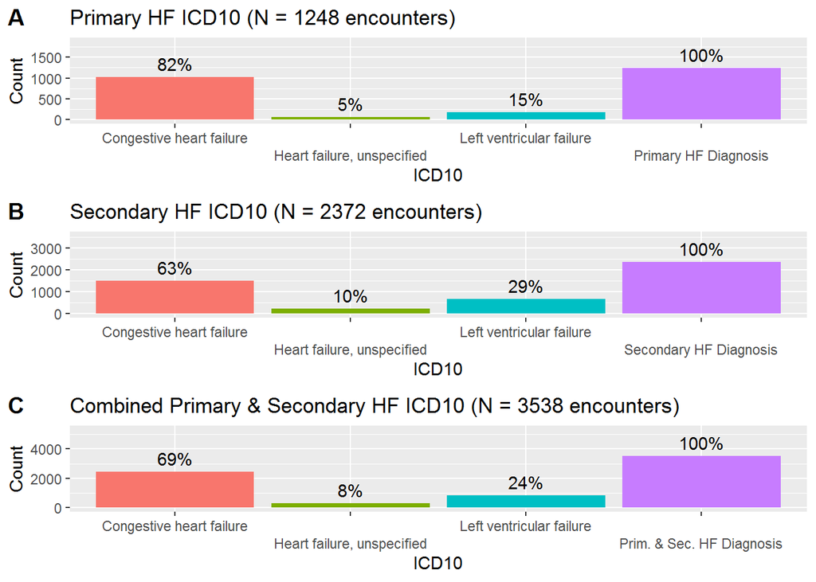

Figure 1.3: Distribution of primary and secondary ICD10 diagnosis.

```r
p1 <- plot_logical_columns(primary_temp,"ICD10","Primary HF ICD10",n_suffix="encounters") +
  scale_x_discrete(guide = guide_axis(n.dodge=2)) +
  ggplot2::ylim(0,nrow(primary_temp)*1.5)

p2 <- plot_logical_columns(secondary_temp,"ICD10","Secondary HF ICD10",n_suffix="encounters") +
  scale_x_discrete(guide = guide_axis(n.dodge=2))+
  ggplot2::ylim(0,nrow(secondary_temp)*1.5)

p3 <- plot_logical_columns(combined_temp,"ICD10","Combined Primary & Secondary HF ICD10",n_suffix="encounters") +
  scale_x_discrete(guide = guide_axis(n.dodge=2))+
  ggplot2::ylim(0,nrow(combined_temp)*1.5)

ggpubr::ggarrange(p1,p2,p3,labels= c("A","B","C"), ncol = 1, nrow = 3)
```

```r
prim_sec_merge <- primary_temp %>%
  dplyr::inner_join(secondary_temp,by="ENCNTR_ID",suffix = c("_PRIMARY","_SECONDARY")) %>%
  dplyr::mutate(PRIMARY_DIAG =
                  dplyr::case_when(
                    `Congestive heart failure_PRIMARY` ~ "Congestive heart failure",
                    `Left ventricular failure_PRIMARY` ~ "Left ventricular failure",
                    `Heart failure, unspecified_PRIMARY` ~ "Heart failure, unspecified",
                  ),
                SECONDARY_DIAG =
                  dplyr::case_when(
                    `Congestive heart failure_SECONDARY` ~ "Congestive heart failure",
                    `Left ventricular failure_SECONDARY` ~ "Left ventricular failure",
                    `Heart failure, unspecified_SECONDARY` ~ "Heart failure, unspecified",
                  )
                )
```

```r
diag_tab <- prop.table(table(prim_sec_merge$PRIMARY_DIAG,prim_sec_merge$SECONDARY_DIAG))
```

An encounter can also be associated with both a primary and secondary heart failure ICD10, where **2.3**% (**82**/**3538**) of encounters have both a primary and secondary heart failure ICD10 diagnosis . Table 1.1 shows the encounters with both a primary and secondary HF diagnosis (n = **82**) and the proportion of this selection with different combinations of primary and secondary diagnosis. For example, **80.5**% of these encounters have both a primary and secondary diagnosis of **congestive heart failure**. This is explained by coding occurring at the episode level and encounters may have >1 episode.

```r
tab_caption <- paste0("Contingency table of Primary and Secondary HF Diagnosis (N = ",
                      nrow(prim_sec_merge),"/",nrow(combined_temp),")")
diag_tab %>%
  knitr::kable(caption = tab_caption,digits=2) %>%
  kableExtra::add_header_above(c("Primary ICD10"=1,"Secondary ICD10"=3))%>%
  kable_styling(position = "center",full_width = FALSE)
```

Table 1.1: Contingency table of Primary and Secondary HF Diagnosis (N = 82/3538)

| Primary ICD10 | Secondary ICD10 Congestive heart failure | Secondary ICD10 Heart failure, unspecified | Secondary ICD10 Left ventricular failure |
| --- | --- | --- | --- |
| Congestive heart failure | 0.80 | 0.02 | 0.01 |
| Heart failure, unspecified | 0.00 | 0.02 | 0.00 |
| Left ventricular failure | 0.01 | 0.02 | 0.10 |

```r
only_secondary <- secondary_temp %>%
  dplyr::filter(!ENCNTR_ID %in% primary_temp$ENCNTR_ID)
n_only_prim <-  nrow(only_secondary)

primary_diag_of_secondary <- diagnosis %>%
  dplyr::filter(!stringr::str_detect(SOURCE_IDENTIFIER,"(?i)I50") &
                  ENCNTR_ID %in% only_secondary$ENCNTR_ID &
                  DIAG_PRIORITY == 1 &
                  SOURCE_VOCABULARY_CD == "ICD10-AM")

tab_cap <- paste(
  "Top 15 primary diagnosis for those with only a secondary heart failure diagnosis (N =",
  n_only_prim,
  "encounters).",
  sep=" "
)

tab <- primary_diag_of_secondary %>%
  dplyr::group_by(SOURCE_STRING) %>%
  dplyr::summarise(N = dplyr::n_distinct(ENCNTR_ID)) %>%
  dplyr::mutate(prop = round(N/dplyr::n_distinct(primary_diag_of_secondary$PERSON_ID)*100,1)) %>%
  dplyr::arrange(desc(N)) %>%
  dplyr::top_n(15)


tab_names <- tab %>%
  dplyr::filter(!stringr::str_detect(SOURCE_STRING,"(?i)awaiting admission"))
```

Table 1.2 shows the primary diagnosis of those encounters with **ONLY** secondary heart failure diagnosis (n = **2290**). The data shows that these encounters are also commonly associated with **pneumonia, unspecified**, as well as diagnoses such as **atrial fibrillation and atrial flutter, unspecified** or a **acute subendocardial myocardial infarction**.

```r
tab %>%
  knitr::kable(caption = tab_cap)
```

Table 1.2: Top 15 primary diagnosis for those with only a secondary heart failure diagnosis (N = 2290 encounters).

| SOURCE_STRING | N | prop |
| --- | --- | --- |
| Pneumonia, unspecified | 145 | 7.3 |
| Atrial fibrillation and atrial flutter, unspecified | 138 | 7.0 |
| Acute subendocardial myocardial infarction | 117 | 5.9 |
| Person awaiting admission to rehabilitation facility/unit | 74 | 3.7 |
| Person awaiting admission to residential aged care service | 73 | 3.7 |
| Aortic (valve) stenosis | 60 | 3.0 |
| Cellulitis of lower limb | 49 | 2.5 |
| Acute transmural myocardial infarction of anterior wall | 48 | 2.4 |
| Chronic obstructive pulmonary disease with acute lower respiratory infection | 47 | 2.4 |
| Atherosclerotic heart disease, of native coronary artery | 44 | 2.2 |
| Sepsis, unspecified | 41 | 2.1 |
| Acute kidney failure, unspecified | 35 | 1.8 |
| Dyspnoea | 31 | 1.6 |
| Pneumonitis due to food and vomit | 30 | 1.5 |
| Person awaiting admission to other health care facility | 27 | 1.4 |

```r
primary_cohort <- cohort %>%
  dplyr::filter(PERSON_ID %in% hf_diag_primary$PERSON_ID) %>%
  dplyr::mutate(HAS_PRIMARY_HF = TRUE)


AGE_breaks <- c(-Inf,18, 25, 45, 65, 80, Inf)
  AGE_labels <- c("<18", "19-24", "25-44", "45-64", "65-80", "80+")

primary_enc <- encounter %>%
  dplyr::filter(ENCNTR_ID %in% hf_diag_primary$ENCNTR_ID) %>%
  dplyr::left_join(patient, by = "PERSON_ID") %>%
  dplyr::mutate(AGE = as.integer(difftime(ACTIVE_STATUS_DT_TM,BIRTH_DT_TM, units="weeks")/52.25))%>%
  dplyr::mutate(AGE_BINNED = cut(AGE, breaks = AGE_breaks, labels = AGE_labels,
                                   right = FALSE)) %>%
    dplyr::mutate(LOS = difftime(DISCH_DT_TM,ARRIVE_DT_TM,units="days")) %>%
  dplyr::left_join(primary_temp, by="ENCNTR_ID") %>%
  dplyr::mutate(PRIMARY_DIAG =
                  dplyr::case_when(
                    `Congestive heart failure` ~ "Congestive heart failure",
                    `Left ventricular failure` ~ "Left ventricular failure",
                    `Heart failure, unspecified` ~ "Heart failure, unspecified",
                  ))
```

The cohort that will be analysed for the rest of this document are those encounters with a primary heart failure diagnosis.

# 2 Demographics in patients with encounters containing a primary HF ICD10 code

With these selection and exclusion criteria, the cohort for this analysis will include **1248** number of encounters for **952** unique patients with the following demographics.

```r
primary_demo <- primary_enc %>%
  dplyr::group_by(PERSON_ID) %>%
  dplyr::arrange(AGE) %>%
  dplyr::slice(1) %>%
  dplyr::ungroup()

total<- bind_rows(primary_demo, mutate(primary_demo, SEX_CD = "Total")) %>%
  group_by(SEX_CD) %>%
  summarise(
    N = n(),
    Age = round(mean(AGE)),
  ) %>%
  pivot_wider(names_from = "SEX_CD", values_from = c("N", "Age")) %>%
  mutate(p_Female = round(N_Female/N_Total*100, 1),
         p_Male = round(N_Male/N_Total*100, 1)) %>%
  select(
         Females = N_Female, p_Female,
         Males = N_Male, p_Male,
         N_Total,
         Age_Female,
         Age_Male,
         Age_Total) %>%
  flextable() %>%
  set_header_labels(Group = "", p_Female = "%", p_Male = "%", N_Total = "n",
                    Age_Female = "Age (F)", Age_Male = "Age (M)", Age_Total = "Mean Age")
total
```

| Females | % | Males | % | n | Age (F) | Age (M) | Mean Age |
| --- | --- | --- | --- | --- | --- | --- | --- |
| 444 | 46.6 | 508 | 53.4 | 952 | 83 | 80 | 81 |

Figure 2.1 shows the distribution of sex according to age groups.

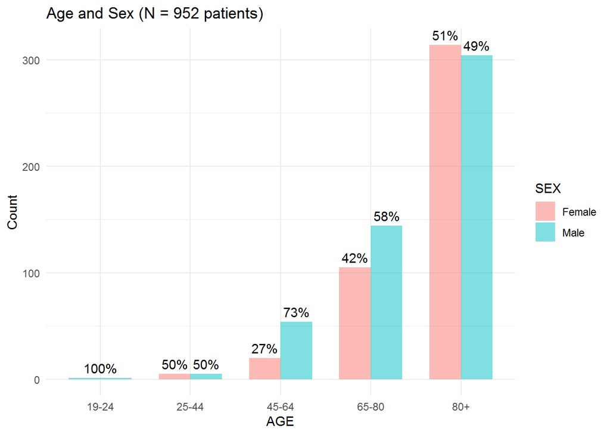

Figure 2.1: Distribution of Sex conditioned on Age.

```r
conditional_bar_plot(primary_demo,"AGE_BINNED","SEX_CD", "Age and Sex",n_suffix="patients") +
  scale_fill_discrete(name = "SEX") +
  xlab("AGE")
```

```r
admission_mode_count <- primary_enc %>%
  dplyr::group_by(ADMIT_MODE_CD) %>%
  dplyr::summarise(N = dplyr::n()) %>%
  dplyr::arrange(desc(N)) %>%
  dplyr::filter(ADMIT_MODE_CD != "NDF")

sep_mode_count <- primary_enc %>%
  dplyr::group_by(DISCH_DISPOSITION_CD) %>%
  dplyr::summarise(N = dplyr::n())%>%
  dplyr::arrange(desc(N))%>%
  dplyr::filter(DISCH_DISPOSITION_CD != "NDF")
```

Figure 2.2 shows the distribution of admission and discharges modes for these encounters with a primary HF diagnosis. Arrival by **State Ambulance Vehicle** is the most prevalent mode of admission followed by **Private Car** then **No Transport (Walked In)**. On the other hand, the top 3 discharge modes were, **Discharge by Hospital**, followed by **Transfer to Hospital in the area/region** then **Pt Death without Autopsy**.

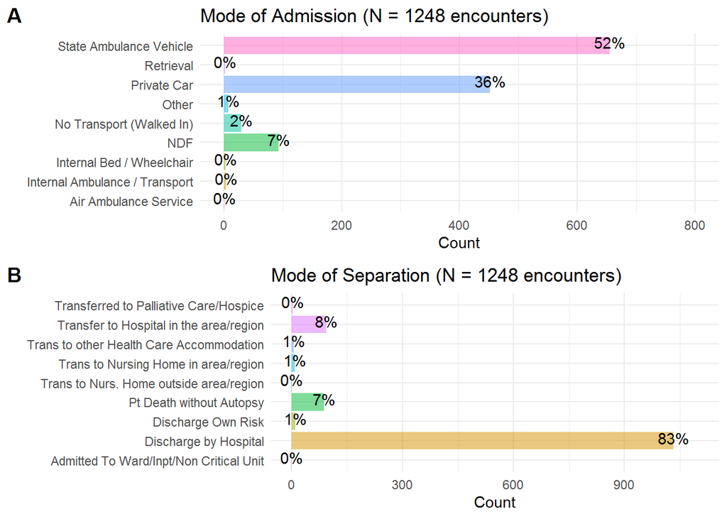

Figure 2.2: Admission and Discharge mode of encounters with primary HF diagnosis.

```r
p1 <- proportion_bar_plot(primary_enc,"ADMIT_MODE_CD","Mode of Admission",n_suffix="encounters",vjust=0.25) + ylim(0,800) +xlab("")  + coord_flip()

p2 <- proportion_bar_plot(primary_enc,"DISCH_DISPOSITION_CD","Mode of Separation",n_suffix="encounters",vjust=0.25)  + ylim(0,1100) +xlab("")  + coord_flip()


ggpubr::ggarrange(p1,p2,nrow=2,ncol = 1, labels=c("A","B"))
```

Figure 2.3**A** shows the distribution of the length of stay (LOS) with a red line marking the median LOS (**5.6** days) and Figure 2.3**B** shows the distribution of LOS by diagnosis. Furthermore, Table 2.1 shows various statistics of the LOS by diagnosis. Encounters with either a missing admission or discharge date have been excluded.

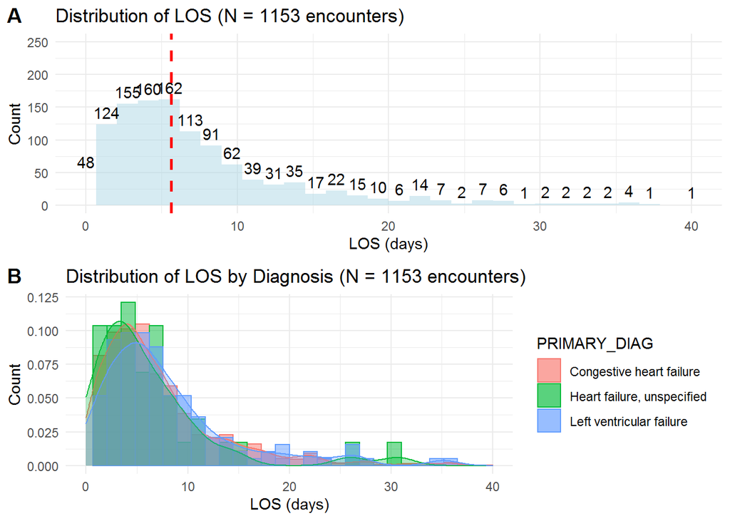

Figure 2.3: Distribution of Length of Stay

```r
p1 <- plot_histogram(primary_enc %>% dplyr::filter(!is.na(LOS)),"LOS","Distribution of LOS",median(primary_enc$LOS,na.rm=TRUE),n_suffix = "encounters") + xlab("LOS (days)") + xlim(0,40) + ylim(0,250)

p2 <- plot_histogram_group(primary_enc %>% dplyr::filter(!is.na(LOS)),"LOS","PRIMARY_DIAG","Distribution of LOS by Diagnosis",n_suffix = "encounters") + xlab("LOS (days)") + xlim(0,40)

ggpubr::ggarrange(p1,p2,nrow=2,ncol = 1, labels=c("A","B"))
```

```r
primary_enc %>%
  dplyr::bind_rows(mutate(primary_enc, PRIMARY_DIAG = "Total")) %>%
  dplyr::filter(!is.na(LOS)) %>%
  dplyr::group_by(PRIMARY_DIAG) %>%
  dplyr::summarise(MEAN = as.numeric(round(mean(LOS),1)),
                   MAX = as.numeric(round(max(LOS),1)),
                   MIN = as.numeric(round(min(LOS),1)),
                   MEDIAN = as.numeric(round(median(LOS),1)),
                   STD = as.numeric(round(sd(LOS),1)),
                   N = dplyr::n()) %>%
  flextable() %>%
  set_caption("Statistics of LOS by HF diagnosis.")
```

Table 2.1: Statistics of LOS by HF diagnosis.

| PRIMARY_DIAG | MEAN | MAX | MIN | MEDIAN | STD | N |
| --- | --- | --- | --- | --- | --- | --- |
| Congestive heart failure | 8.0 | 316.9 | 0.2 | 5.6 | 12.8 | 971 |
| Heart failure, unspecified | 6.2 | 30.7 | 0.2 | 4.4 | 6.1 | 42 |
| Left ventricular failure | 7.9 | 35.2 | 0.3 | 6.2 | 6.7 | 140 |
| Total | 7.9 | 316.9 | 0.2 | 5.6 | 12.1 | 1,153 |

```r
ferric_carboxy <- execute_query("select * from MEDICATION_ORDERS
where CATALOG_CD like '%carboxy%'")

ferric_carboxy %>%
  dplyr::group_by(ORDERED_AS_MNEMONIC) %>%
  dplyr::summarise(N = dplyr::n()) %>%
  flextable() %>%
  autofit() %>%
  set_caption("Ferric carboxymaltose orders in the NSLHD EMR and the total number of counts.")
```

Table 2.2: Ferric carboxymaltose orders in the NSLHD EMR and the total number of counts.

| ORDERED_AS_MNEMONIC | N |
| --- | --- |
| Ferinject | 553 |
| Ferinject 50 mg/mL intravenous solution | 17 |
| ferric carboxymaltose | 286 |
| ferric carboxymaltose (as elemental iron) 50 mg/mL intravenous solution | 2 |

```r
primary_enc_iv <- primary_enc %>%
  dplyr::mutate(HAS_FERRIC = ENCNTR_ID %in% ferric_carboxy$ENCNTR_ID) %>%
  dplyr::mutate(BELOW_MEDIAN_LOS = LOS < median(LOS,na.rm=TRUE))
```

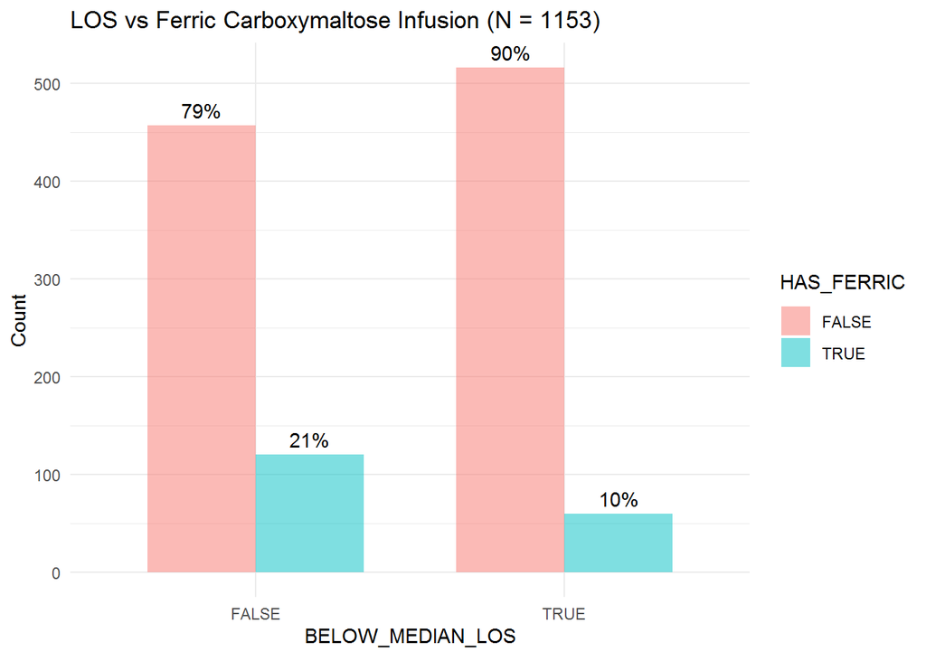

Figure 2.4: Proportion of encounters with LOS below the median with an ferric carboxymaltose IV infusion.

```r
primary_enc_iv %>%
  dplyr::filter(!is.na(BELOW_MEDIAN_LOS)) %>%
conditional_bar_plot("BELOW_MEDIAN_LOS", "HAS_FERRIC","LOS vs Ferric Carboxymaltose Infusion")
```

## 2.1 Comparison with CaseMix App

The above numbers were compared against the in-house `Admitted Patient CaseMix app` developed by the NSLHD Performance and Analytics team that shows the numbers of encounters and their characteristics of each ICD10 diagnosis.

Figure 2.5 shows that there are a similar number of encounters with a primary heart failure ICD10 diagnosis over a the same period of time at **Royal North Shore**. Furthermore the distribution of ICD10 codes are comparable between the current cohort and the NSLHD Performance and Analytics team.

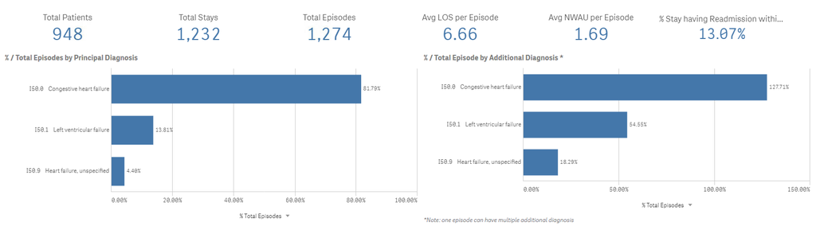

Figure 2.5: Distribution of ICD10 heart failure encounters using the `Admitted Patient CaseMix App.

```r
# All defaults
file <-paste0("vignettes/img/inpatient_hf_casemix_",tolower(stringr::str_replace_all(location_string," ","_")),".PNG")
knitr::include_graphics(file.path(here::here(),file))
```

# 3 Advanced Care Directive

The Advanced Care Directive is represented in the EMR as an alert with the string **Known to Heart Failure Support Services**.

```r
known_to_hf <- problem %>%
  dplyr::filter(stringr::str_detect(SOURCE_STRING,"(?i)Known to heart failure")) %>%
  dplyr::group_by(PERSON_ID) %>%
  dplyr::arrange(BEG_EFFECTIVE_DT_TM) %>%
  dplyr::slice(1) %>%
  dplyr::select(PERSON_ID,BEG_EFFECTIVE_DT_TM) %>%
  dplyr::mutate(HAS_ALERT = TRUE)

kk<- primary_cohort %>%
  merge(.,select(known_to_hf,-BEG_EFFECTIVE_DT_TM) , by="PERSON_ID",all=TRUE) %>%
  replace(is.na(.), FALSE)

prop_tab <- prop.table(table(kk$HAS_PRIMARY_HF,kk$HAS_ALERT))
tab <- table(kk$HAS_PRIMARY_HF,kk$HAS_ALERT)
tab  %>%
  knitr::kable(caption = "Contigency table of Primary HF ICD10 and Advanced Care directive (ACD).",digits=2) %>%
  kableExtra::add_header_above(c("Has Primary\n ICD10"=1,"Has ACD"=2))%>%
  kable_styling(position = "center",full_width = FALSE)
```

Table 3.1: Contigency table of Primary HF ICD10 and Advanced Care directive (ACD).

| Has Primary ICD10 | Has ACD FALSE | Has ACD TRUE |
| --- | --- | --- |
| FALSE | 0 | 936 |
| TRUE | 491 | 461 |

Table 3.1 shows a contingency table of the number of patients with a primary ICD10 code who also have an Advanced Care Directive. The right-most column shows number of patients with a ACD across NSLHD (n = **1397**) and the bottom-most row shows the number of people with a primary HF diagnosis (n = **952**). The combination of the rows and columns show the number of people who have either a ACD or diagnosis, or both or none.

For example, there are **461** patients with both a ACD **AND** a primary heart failure diagnosis. Thus there are **48.4**% of patients (**461/491 + 461**) with a primary HF ICD10 that have an advanced care directive.

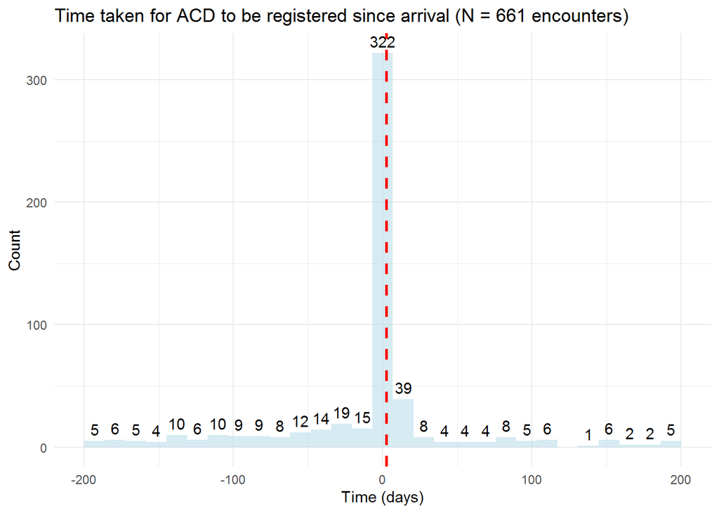

Figure 3.1: Distribution of time taken to register Advanced Care Directive since admission for the encounter.

```r
primary_enc_alert <- primary_enc %>%
  dplyr::left_join(known_to_hf,by="PERSON_ID") %>%
  dplyr::mutate(ALERT_DELTA = difftime(BEG_EFFECTIVE_DT_TM,ARRIVE_DT_TM,units="days")) %>%
  tidyr::replace_na(list(HAS_ALERT=FALSE))

plot_histogram(
  primary_enc_alert %>%
    dplyr::filter(!is.na(ALERT_DELTA)),
  "ALERT_DELTA","Time taken for ACD to be registered since arrival",
  median(primary_enc_alert$ALERT_DELTA,na.rm=TRUE),n_suffix = "encounters") + xlim(-200,200) + xlab("Time (days)")
```

```r
n_1_alert <- primary_enc_alert %>%
  dplyr::filter(ALERT_DELTA < 1) %>%
  nrow()

n_3_alert <- primary_enc_alert %>%
  dplyr::filter(ALERT_DELTA < 3) %>%
  nrow()

n_alert <- primary_enc_alert %>%
  dplyr::filter(!is.na(HAS_ALERT)) %>%
  nrow()

median <- as.numeric(median(primary_enc_alert$ALERT_DELTA,na.rm=TRUE))
```

Figure 3.1 shows the distribution of the time taken for the ACD to be registered in the EMR since admission with the median of **2.3** days being marked by the red dashed line. Time differences that are less than 0 means that the ACD was already present when that person was admitted. The data shows that **18**% of alerts are registered within 1 day of admission and **30.3**% within 3 days of admission.

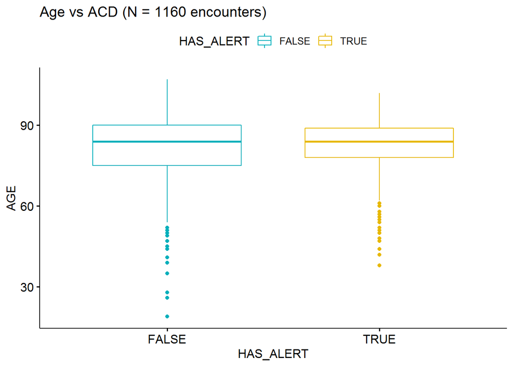

Figure 3.2: Boxplot of Age and whether the encounter has had a ACD or not. Encounters that resulted in patient being deceased are excluded.

```r
primary_alert_before_during_enc <- primary_enc_alert %>%
  dplyr::filter(DEPART_DT_TM >= BEG_EFFECTIVE_DT_TM | ALERT_DELTA <= 0)
# ALERT_DELTA <= 0  | ACTIVE_STATUS_DT_TM <=  BEG_EFFECTIVE_DT_TM &
primary_enc_no_deaths<-primary_enc_alert %>%
  dplyr::filter(DISCH_DISPOSITION_CD != "Pt Death without Autopsy") %>%
  dplyr::mutate(HAS_ALERT = ENCNTR_ID %in% primary_alert_before_during_enc$ENCNTR_ID)



primary_enc_no_deaths %>%
  ggpubr::ggboxplot(x = "HAS_ALERT", y = "AGE",
          color = "HAS_ALERT", palette = c("#00AFBB", "#E7B800"),
          ylab = "AGE", xlab = "HAS_ALERT",title=paste0("Age vs ACD (N = ",nrow(primary_enc_no_deaths)," encounters)"))
```

```r
mean <- primary_enc_no_deaths %>%
    dplyr::group_by(HAS_ALERT) %>%
    dplyr::summarise(mean = mean(AGE))
```

Figure 3.2 shows a boxplot of `AGE` against whether the patient has had an ACD or not (`HAS_ALERT`). The presence of an ACD is determined as by whether the ACD was registered before the beginning of the admission or during the admission. The plot suggests that the means the `AGE` of the group with an ACD is higher compared to the group without an ACD (**82** vs **81.4**, respectively). Furthermore the group without an ACD has larger variance w.r.t `AGE`.

Figure 3.3 shows the conditional distribution of the cohort’s age and the likelihood that they will have an ACD. The plot suggests that older members are more likely to have an alert and less likely to have an alert if the patient is in the younger age groups, `19-24`,`25-44` and `45-64`.

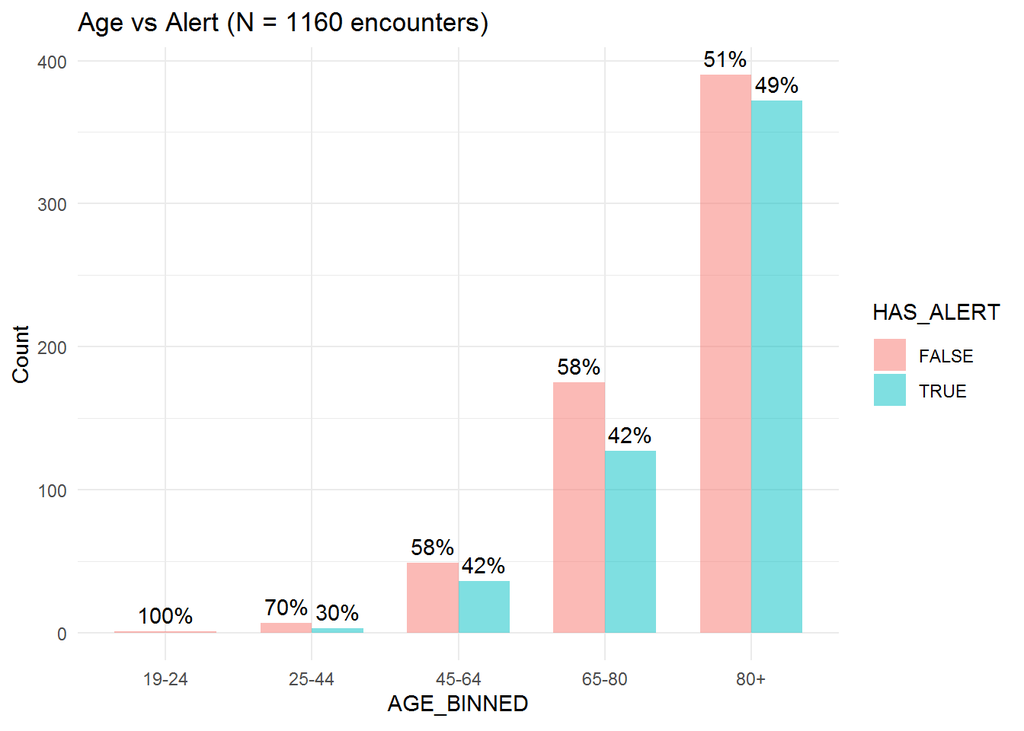

Figure 3.3: Likelihood of having an ACD given the patient’s age.

```r
conditional_bar_plot(primary_enc_no_deaths,"AGE_BINNED","HAS_ALERT","Age vs Alert",n_suffix = "encounters")
```

```r
res.aov <- aov(AGE ~ HAS_ALERT, data = primary_enc_no_deaths)
summary_results <- summary(res.aov)[[1]]
summary_results %>%
  round(2) %>%
  flextable() %>%
  autofit() %>%
  set_caption("One-way ANOVA test of age against having a ACD or not.")
```

Table 3.2: One-way ANOVA test of age against having a ACD or not.

| Df | Sum Sq | Mean Sq | F value | Pr(>F) |
| --- | --- | --- | --- | --- |
| 1 | 109.43 | 109.43 | 0.87 | 0.35 |
| 1,158 | 145,981.82 | 126.06 |  |  |

Table 3.2 shows the results of a one-way ANOVA with the null hypothesis being that there is no difference in the means of ages between the group that has an ACD to one that does not have an ACD. With a p value of **0.352**, the test suggests that there is no statistically significant difference between the two groups to reject the null.

# 4 Historical Diagnosis

A historical diagnosis for a patient is defined as a HF ICD10 diagnosis (either primary or secondary) that was coded within the last three years of the patient’s first HF diagnosis between **2019** to **2021**. For example, if a patient had been diagnosed with HF in 2018 and 2020, that patient would have been considered to have a historical HF diagnosis if they were diagnosed between 2015 and their encounter in 2018.

Figure 4.1 shows whether or not a patient has has a historical diagnosis of HF and if so, the coded HF diagnosis. The plot demonstrates that most patients have had no previous HF diagnosis since entering the cohort.

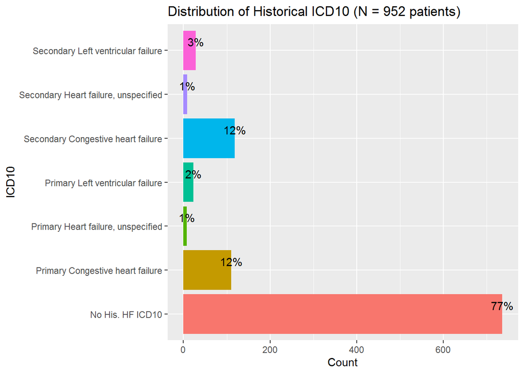

Figure 4.1: Distribution of historical diagnosis.

```r
his_hf_diag <- diagnosis_history %>%
  dplyr::filter(stringr::str_detect(SOURCE_IDENTIFIER,"(?i)I50") &
                  PERSON_ID %in% primary_cohort$PERSON_ID)

summary_his_diag <- his_hf_diag %>%
  extract_hf_diagnosis(group_cols = "PERSON_ID",split_priority = TRUE) %>%
  dplyr::right_join(primary_cohort,by="PERSON_ID") %>%
  dplyr::select(-HAS_PRIMARY_HF) %>%
  replace(is.na(.),FALSE) %>%
    dplyr::mutate(`No His. HF ICD10` = !`Primary Congestive heart failure` & !`Primary Heart failure, unspecified`
                  & !`Primary Left ventricular failure` & !`Secondary Congestive heart failure` &
                    !`Secondary Heart failure, unspecified`
                  & !`Secondary Left ventricular failure`)
plot_logical_columns(summary_his_diag,"ICD10","Distribution of Historical ICD10",n_suffix="patients") +coord_flip()
```

# 5 Orders

```r
echos <- orders %>%
  dplyr::filter(stringr::str_detect(CATALOG_CD,"(?i)cardio - echo") & ENCNTR_ID %in% primary_enc$ENCNTR_ID) %>%
  dplyr::group_by(ENCNTR_ID) %>%
  dplyr::arrange(desc(STATUS_DT_TM)) %>%
  dplyr::slice(1) %>%
  dplyr::select(ENCNTR_ID,PERSON_ID,CATALOG_CD,STATUS_DT_TM) %>%
  dplyr::right_join(
    dplyr::select(primary_enc,ENCNTR_ID,ARRIVE_DT_TM),by="ENCNTR_ID") %>%
  dplyr::mutate(HAS_ECHO = !is.na(CATALOG_CD),ECHO_DELTA = difftime(STATUS_DT_TM,ARRIVE_DT_TM,units = "days")) %>%
  dplyr::ungroup() %>%
  dplyr::select(-CATALOG_CD) %>%
  dplyr::rename(ECHO_START_DT_TM = STATUS_DT_TM)
```

```r
extract_path_result <- function(df,regex,prefix,breaks=NULL,labels=NULL){
  df %<>% dplyr::filter(stringr::str_detect(EVENT_CD,regex)) %>%
  dplyr::select(ENCNTR_ID,PERSON_ID,EVENT_START_DT_TM,RESULT_VAL,RESULT_UNITS_CD) %>%
    dplyr::mutate(RESULT_VAL = as.numeric(stringr::str_remove_all(RESULT_VAL, '\"')) )  %>%
  dplyr::rename("{prefix}_EVENT_START_DT_TM" := EVENT_START_DT_TM,

                "{prefix}_RESULT_UNITS_CD" := RESULT_UNITS_CD)

  if(!is.null(breaks)){
    df %<>% dplyr::mutate("{prefix}_BIN" := cut(RESULT_VAL,breaks=breaks,labels=labels))
  }
  df %<>% dplyr::rename("{prefix}_RESULT_VAL" := RESULT_VAL)

  return(df)
}
```

```r
path_tests_full <- execute_query("SELECT * from PATHOLOGY_EVENT where CATALOG_CD = 'Brain Natriuretic Peptide' or CATALOG_CD = 'Iron Level' or CATALOG_CD = 'Iron Studies' or CATALOG_CD = 'N Terminal Pro Brain Natriuretic Peptide'")

path_tests  <-  path_tests_full %>%
  dplyr::filter(ENCNTR_ID %in% primary_enc$ENCNTR_ID) %>%
  dplyr::mutate(EVENT_CD = dplyr::case_when(
    stringr::str_detect(EVENT_CD,"(Brain Natriuretic peptide)|(N Terminal pro BNP)|(NT-ProBNP)") ~ "BNP",
    TRUE ~ EVENT_CD
  )) %>%
  dplyr::group_by(ENCNTR_ID,EVENT_CD) %>%
  dplyr::arrange(desc(EVENT_START_DT_TM)) %>%
  dplyr::slice(1) %>%
  dplyr::ungroup()
```

```r
path_tests_full %>%
  dplyr::group_by(EVENT_CD) %>%
  dplyr::filter(ENCNTR_ID %in% primary_enc$ENCNTR_ID) %>%
  dplyr::summarise(N = dplyr::n()) %>%
  flextable() %>%
  autofit() %>%
  set_caption("List of strings related to iron and BNP and their counts.")
```

Table 5.1: List of strings related to iron and BNP and their counts.

| EVENT_CD | N |
| --- | --- |
| Brain Natriuretic peptide (BNP ) | 311 |
| Ferritin | 551 |
| Haematinics Comment | 9 |
| Iron | 552 |
| N Terminal pro BNP (NT proBNP) | 687 |
| NT-ProBNP | 2 |
| Transferrin Saturation | 551 |
| Transferrin. | 552 |

```r
bnp <- extract_path_result(path_tests,"BNP", "BNP", c(-Inf,450,900,Inf),c("< 450","450-900","900+"))
iron <- extract_path_result(path_tests,"Iron", "IRON",c(-Inf,9,30.4,Inf),c("< 9","9-30.4","30.4+"))
trans_sat <- extract_path_result(path_tests,"Transferrin Saturation", "TRANSFERRIN_SAT",c(-Inf,20,Inf),c("< 20","20+"))

hf_order<-echos  %>%
  dplyr::left_join(
    bnp, by="ENCNTR_ID"
  ) %>%
  dplyr::left_join(
    iron, by="ENCNTR_ID"
  ) %>%
  dplyr::left_join(
    trans_sat, by="ENCNTR_ID"
  ) %>%
  dplyr::mutate(HAS_BNP = !is.na(BNP_EVENT_START_DT_TM),
                HAS_IRON = !is.na(IRON_EVENT_START_DT_TM),
                HAS_TRANSFERRIN_SAT = !is.na(TRANSFERRIN_SAT_EVENT_START_DT_TM))




order_year_join <- function(cohort,df,time_col){
  time_col <- rlang::sym(time_col)
  cohort %<>%
    dplyr::select(PERSON_ID,ARRIVE_DT_TM,ENCNTR_ID) %>%
    dplyr::left_join(df,by="PERSON_ID",suffix=c("","_ORDER")) %>%
    dplyr::mutate(DELTA = difftime(!!time_col,ARRIVE_DT_TM,units="days")) %>%
    dplyr::filter((DELTA >= -365.25 & DELTA <= 0) | ENCNTR_ID == ENCNTR_ID_ORDER)

  return(cohort)
}
```

```r
cardio_echo_orders <- orders %>%
  dplyr::filter(stringr::str_detect(CATALOG_CD,"(?i)cardio - echo"))


echo_year <-  primary_enc %>%
  order_year_join(cardio_echo_orders,"STATUS_DT_TM")




bnp_year <- primary_enc %>%
  order_year_join(bnp,"BNP_EVENT_START_DT_TM")
iron_year <- primary_enc %>%
  order_year_join(iron,"IRON_EVENT_START_DT_TM")
transferrin_sat_year <- primary_enc %>%
  order_year_join(trans_sat,"TRANSFERRIN_SAT_EVENT_START_DT_TM")

primary_orders_in_year<-hf_order %>%
  dplyr::mutate(HAS_ECHO_YEAR = ENCNTR_ID %in% echo_year$ENCNTR_ID,
                HAS_BNP_YEAR = ENCNTR_ID %in% bnp_year$ENCNTR_ID,
                HAS_IRON_YEAR = ENCNTR_ID %in% iron_year$ENCNTR_ID,
                HAS_TRANSFERRIN_SAT_YEAR = ENCNTR_ID %in% transferrin_sat_year$ENCNTR_ID)
```

Figure 5.1**A** shows the proportion of encounters with a relevant heart failure order being echocardiogram, brain natriuretic peptide test, serum iron test and transferrin saturation test of encounters with an order during the encounter. On the other hand, Figure 5.1**B** shows the proportion of encounters with an order during the encounter OR within one last year of the beginning of the encounter’s admission. These proportions in Figure 5.1**B** for all of these orders is slightly higher compared to Figure 5.1**A**.

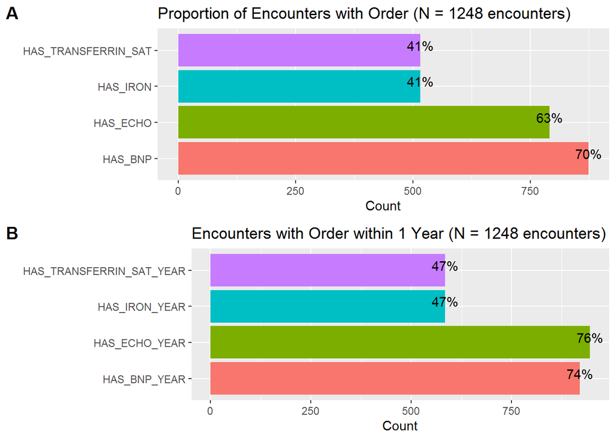

Figure 5.1: Number and proportion of encounters with a relevant heart failure order, echocardiogram, brain natriuretic peptide test, serum iron test and transferrin saturation test during the encounter or within 1 year of the encounter.

```r
p1<-plot_logical_columns(hf_order,"ORDERS","Proportion of Encounters with Order",n_suffix="encounters",vjust=0) + coord_flip() + xlab("")

p2<- primary_orders_in_year %>%
  dplyr::select(contains("_YEAR")) %>%
  plot_logical_columns("ORDERS","Encounters with Order within 1 Year",n_suffix="encounters",vjust=0) + coord_flip() + xlab("")



ggpubr::ggarrange(p1,p2,nrow=2,ncol=1,labels=c("A","B"))
```

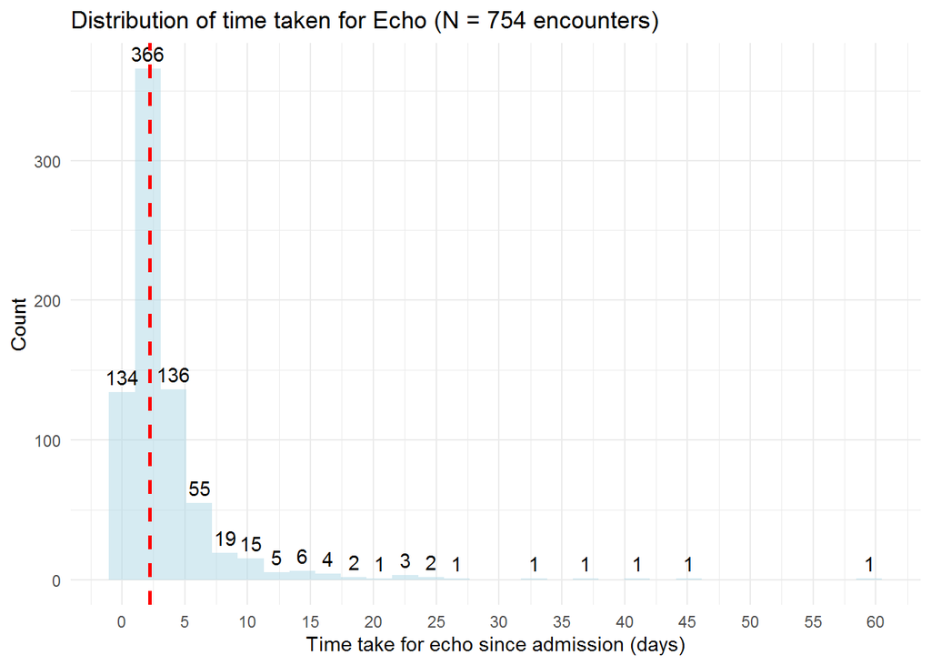

Figure 5.2: Distribution of the time taken for an echocardiogram.

```r
mean_delta <- median(hf_order$ECHO_DELTA,na.rm = TRUE)
plot_histogram(hf_order %>% dplyr::filter(ECHO_DELTA < 75),
               "ECHO_DELTA","Distribution of time taken for Echo",
               mean_delta,n_suffix="encounters") +
    xlab("Time take for echo since admission (days)")
```

```r
orders %>%
  dplyr::filter(stringr::str_detect(CATALOG_CD,"(?i)cardio - echo") & ENCNTR_ID %in% primary_enc$ENCNTR_ID) %>%
  dplyr::group_by(CATALOG_CD) %>%
  dplyr::summarise(N = dplyr::n()) %>%
  flextable() %>%
  autofit() %>%
  set_caption("List of strings containing the term 'cardio - echo' and number of occurences.")
```

Table 5.2: List of strings containing the term ‘cardio - echo’ and number of occurences.

| CATALOG_CD | N |
| --- | --- |
| Cardio - Echo (LV & RV Function, CCF) | 881 |
| Cardio - Echo (Valve,Stroke/TIA, Pericar | 58 |

Table 5.2 shows a list of orders in the EMR containing the term `cardio - echo` and similarly Table 5.1 shows a list of pathology tests and their counts for this cohort.

Furthermore Figure 5.2 shows the distribution of the time taken for an echocardiogram with a median time of **2.2** days.

# 6 Forms

```r
extract_form <- function(df,string,prefix){
  df %<>%
  dplyr::filter(DESCRIPTION == string) %>%
  dplyr::mutate(HAS_FORM = TRUE) %>%
  dplyr::group_by(PERSON_ID) %>%
  dplyr::arrange(desc(FORM_DT_TM)) %>%
  dplyr::slice(1) %>%
  dplyr::select(PERSON_ID,ENCNTR_ID,HAS_FORM,PARENT_ENTITY_ID,FORM_DT_TM) %>%
    dplyr::rename_with(.fn = ~ paste0(prefix,"_",.x))

  return(df)
}
```

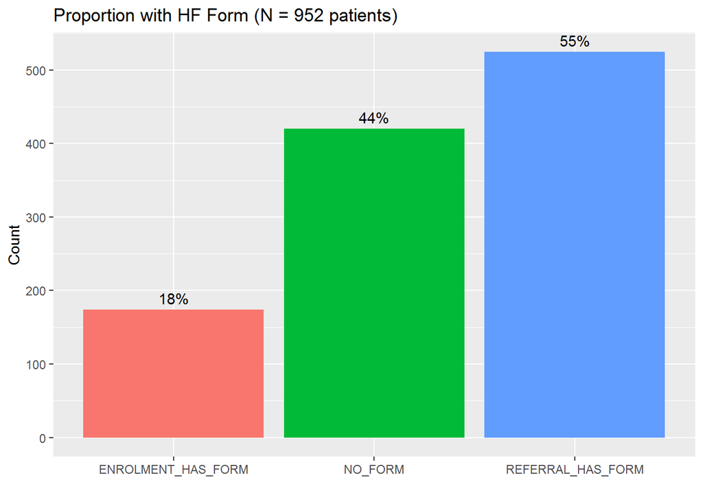

Figure 6.1: Proportion of Patients with an enrolment or referral form.

```r
form_primary_cohort <- primary_cohort %>%
  dplyr::left_join(
    extract_form(hf_form,'Heart Failure - Management of Cardiac Function Enrolment',"ENROLMENT"), by = c("PERSON_ID" = "ENROLMENT_PERSON_ID")
  ) %>%
  dplyr::left_join(
    extract_form(hf_form,'Heart Failure (MACARF) Referral Form',"REFERRAL"), by = c("PERSON_ID" = "REFERRAL_PERSON_ID")
  ) %>%
  tidyr::replace_na(list(ENROLMENT_HAS_FORM = FALSE, REFERRAL_HAS_FORM = FALSE)) %>%
  dplyr::mutate(NO_FORM = !ENROLMENT_HAS_FORM & !REFERRAL_HAS_FORM)

form_primary_cohort %>%
  dplyr::select(-HAS_PRIMARY_HF) %>%
  plot_logical_columns("Form","Proportion with HF Form",n_suffix="patients") +
 labs(x="")
```

Figure 6.1 shows the proportion of patients who have had a referral form or enrolment form completed in the EMR.

Figure 6.2 shows the discharge modes for patients without either a referral nor an enrolment form (n = **420**).

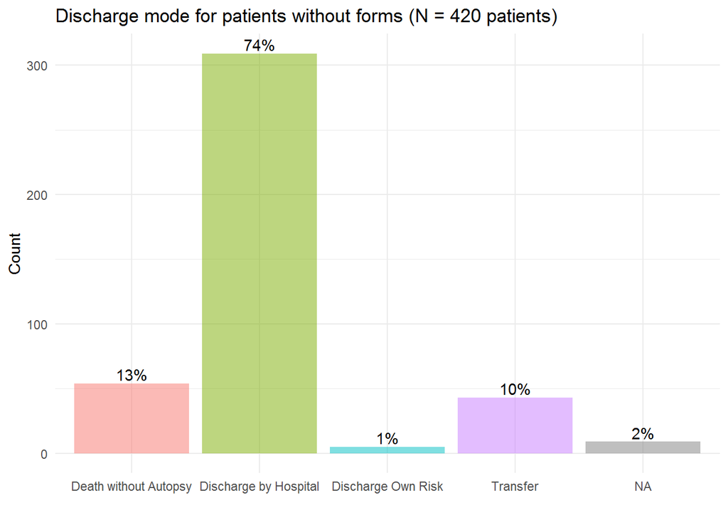

Figure 6.2: Distribution of mode of discharge for patients without either a referral nor enrolment form.

```r
form_primary_cohort %>%
  dplyr::filter(NO_FORM) %>%
  dplyr::left_join(primary_enc,by="PERSON_ID") %>%
  dplyr::group_by(PERSON_ID) %>%
  dplyr::summarise(
    DISCH_MODE = dplyr::case_when(
      any(DISCH_DISPOSITION_CD == 'Pt Death without Autopsy') ~ 'Death without Autopsy',
      any(DISCH_DISPOSITION_CD == 'Discharge Own Risk') ~ 'Discharge Own Risk',
      any(stringr::str_detect(DISCH_DISPOSITION_CD, "(?i)transfer")) ~ 'Transfer',
      any(DISCH_DISPOSITION_CD == "Discharge by Hospital") ~ "Discharge by Hospital",
    )
  ) %>%
  proportion_bar_plot("DISCH_MODE","Discharge mode for patients without forms",n_suffix="patients") + xlab("")
```

```r
convert_year_half_period <- function(df,date_col){
  date_col <- rlang::sym(date_col)
  df %<>%
    dplyr::mutate(YEAR_HALF = as.character(zoo::as.yearqtr(!!date_col)),
                HAS_FORM=TRUE) %>%
    dplyr::mutate(YEAR_HALF = stringr::str_replace(YEAR_HALF,"Q(1|2)","P1"),
                YEAR_HALF = stringr::str_replace(YEAR_HALF,"Q(3|4)","P2"))

  return(df)

}

extract_form_with_year_period <- function(df,string,prefix){
  df %<>% dplyr::filter(DESCRIPTION == string) %>%
    convert_year_half_period("FORM_DT_TM") %>%
  dplyr::select(PERSON_ID,ENCNTR_ID,PARENT_ENTITY_ID,FORM_DT_TM,YEAR_HALF,HAS_FORM) %>%
  dplyr::group_by(PERSON_ID,YEAR_HALF) %>%
  dplyr::arrange(desc(FORM_DT_TM)) %>%
  dplyr::slice(1) %>%
    dplyr::rename_with(.fn = ~ paste0(prefix,"_",.x))

  return(df)
}
```

Figure 6.3 shows the proportion of encounters with either an enrolment, referral form or neither by periods of 6 months where `P1` represents `Jan-Jun` and `P2` represents `Jul-Dec`. Figure 6.3 shows that the proportion with enrolment forms is increasing over the **2.6** year period and that particularly in `2021 P1` an increasing percentage of referrals also have an enrolment form.

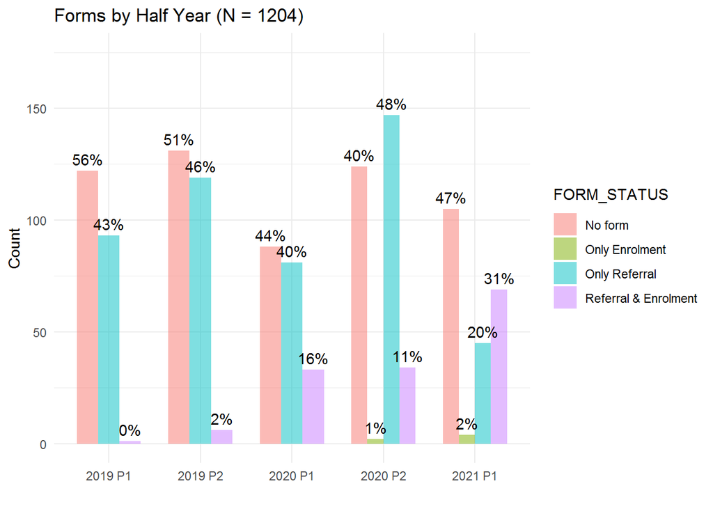

Figure 6.3: Proportion of encounters with a form by half year periods.

```r
enrolment_form <- hf_form %>%
  extract_form_with_year_period('Heart Failure - Management of Cardiac Function Enrolment',"ENROLMENT")


referral_form <- hf_form %>%
   extract_form_with_year_period('Heart Failure (MACARF) Referral Form',"REFERRAL")



temp <- primary_enc %>%
   convert_year_half_period("DISCH_DT_TM")%>%
  dplyr::left_join(enrolment_form,by=c("PERSON_ID" = "ENROLMENT_PERSON_ID",
                                       "YEAR_HALF" = "ENROLMENT_YEAR_HALF")) %>%
  dplyr::left_join(referral_form,by=c("PERSON_ID"= "REFERRAL_PERSON_ID",
                                       "YEAR_HALF" = "REFERRAL_YEAR_HALF")) %>%
   tidyr::replace_na(list(ENROLMENT_HAS_FORM = FALSE, REFERRAL_HAS_FORM = FALSE)) %>%

  dplyr::mutate(FORM_STATUS =
                  dplyr::case_when(
                    !ENROLMENT_HAS_FORM & !REFERRAL_HAS_FORM ~ "No form",
                    REFERRAL_HAS_FORM &  !ENROLMENT_HAS_FORM ~ "Only Referral",
                    !REFERRAL_HAS_FORM &  ENROLMENT_HAS_FORM ~ "Only Enrolment",
                    REFERRAL_HAS_FORM &  ENROLMENT_HAS_FORM ~ "Referral & Enrolment"
                  ))

 temp %>%
   dplyr::filter(YEAR_HALF != "2021 P2") %>%
conditional_bar_plot("YEAR_HALF","FORM_STATUS","Forms by Half Year") + xlab("") + ylim(0,175)
```

# 7 Appendix

## 7.1 Medication for Primary HF Diagnosis

```r
primary_meds <- medication_order %>%
  dplyr::filter(ENCNTR_ID %in% primary_enc$ENCNTR_ID)
primary_enc_meds <- primary_enc %>%
  dplyr::mutate(HAS_DISCH_MED = ENCNTR_ID %in% primary_meds$ENCNTR_ID)
```

Figure 7.1**A** show the proportion of medications that were either a home or one that was ordered for discharged. Figure 7.1**B** shows the proportion of the encounters that were given a discharge medication.

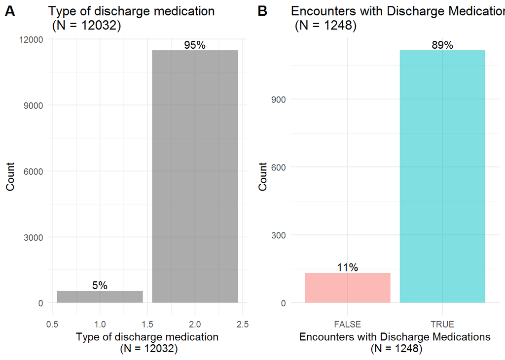

Figure 7.1: The type of medication whether home or discharge medication.

```r
p1 <- proportion_bar_plot(primary_meds,"ORIG_ORD_AS_FLAG","Type of discharge medication\n")
p2 <- proportion_bar_plot(primary_enc_meds,"HAS_DISCH_MED","Encounters with Discharge Medications\n")

ggpubr::ggarrange(p1,p2,ncol=2,nrow=1,labels=c("A","B"))
```

Table 7.1 shows the top 15 medication classes given at discharge or home.

```r
primary_meds %>%
  dplyr::group_by(MEDICATION_CLASS) %>%
  dplyr::summarise(N = dplyr::n_distinct(PERSON_ID)) %>%
  dplyr::mutate(prop = round(N/dplyr::n_distinct(primary_meds$PERSON_ID)*100,1)) %>%
  dplyr::arrange(desc(N)) %>%
  dplyr::top_n(15) %>%
  knitr::kable(caption = "Top 15 discharge medication class.")
```

Table 7.1: Top 15 discharge medication class.

| MEDICATION_CLASS | N | prop |
| --- | --- | --- |
| NDF | 812 | 93.7 |
| beta blockers, cardioselective | 389 | 44.9 |
| loop diuretics | 358 | 41.3 |
| HMG-CoA reductase inhibitors (statins) | 301 | 34.7 |
| factor Xa inhibitors | 238 | 27.5 |
| vitamins | 208 | 24.0 |
| proton pump inhibitors | 201 | 23.2 |
| aldosterone receptor antagonists | 195 | 22.5 |
| minerals and electrolytes | 193 | 22.3 |
| angiotensin converting enzyme (ACE) inhibitors | 186 | 21.5 |
| angiotensin II inhibitors | 137 | 15.8 |
| coumarins and indanediones | 115 | 13.3 |
| group III antiarrhythmics | 114 | 13.1 |
| calcium channel blocking agents | 112 | 12.9 |
| potassium-sparing diuretics | 107 | 12.3 |

## 7.2 Orders for Cohort with Primary HF Diagnosis

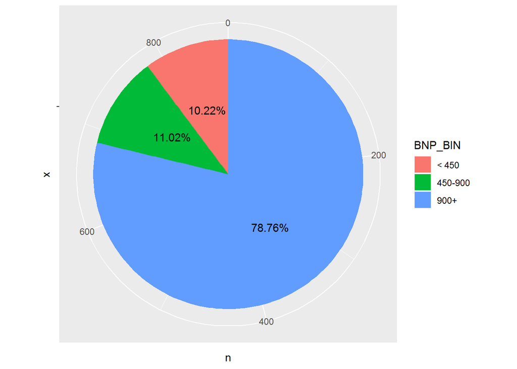

Figure 7.2: Results of pathology tests.

```r
p1<-plot_pie_chart(hf_order,"BNP_BIN","BNP Results by Group")
p2<-plot_pie_chart(hf_order,"IRON_BIN","BNP Results by Group")
p3<-plot_pie_chart(hf_order,"TRANSFERRIN_SAT_BIN","BNP Results by Group")

#ggpubr::ggarrange(p1,p2,p3,nrow=3,ncol=1,labels=c("A","B","C"))


p1
```

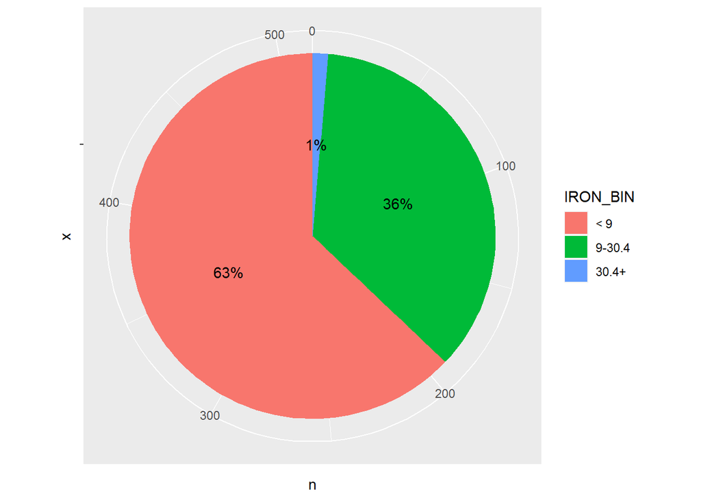

Figure 7.3: Results of pathology tests.

```r
p2
```

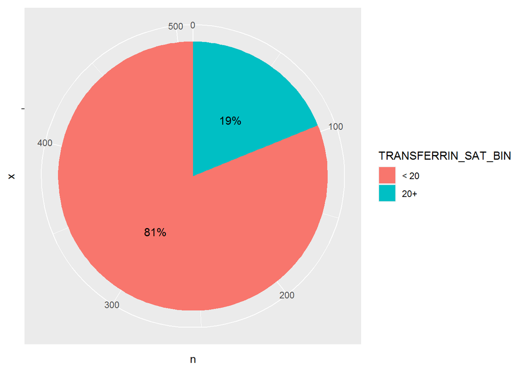

Figure 7.4: Results of pathology tests.

```r
p3
```

## 7.3 Inclusion of Primary and Secondary HF Diagnosis

```r
primary_cohort <- cohort %>%
  dplyr::filter(PERSON_ID %in% qual_enc$PERSON_ID) %>%
  dplyr::mutate(HAS_PRIMARY_HF = TRUE)


AGE_breaks <- c(-Inf,18, 25, 45, 65, 80, Inf)
  AGE_labels <- c("<18", "19-24", "25-44", "45-64", "65-80", "80+")

primary_enc <- qual_enc %>%
  dplyr::left_join(patient, by = "PERSON_ID") %>%
  dplyr::mutate(AGE = as.integer(difftime(ACTIVE_STATUS_DT_TM,BIRTH_DT_TM, units="weeks")/52.25)) %>%
  dplyr::mutate(AGE_BINNED = cut(AGE, breaks = AGE_breaks, labels = AGE_labels,
                                   right = FALSE)) %>%
    dplyr::mutate(LOS = difftime(DISCH_DT_TM,ARRIVE_DT_TM,units="days"))
```

```r
total<- bind_rows(primary_enc, mutate(primary_enc, SEX_CD = "Total")) %>%
  group_by(SEX_CD) %>%
  summarise(
    N = n(),
    Age = round(mean(AGE)),
  ) %>%
  pivot_wider(names_from = "SEX_CD", values_from = c("N", "Age")) %>%
  mutate(p_Female = round(N_Female/N_Total*100, 1),
         p_Male = round(N_Male/N_Total*100, 1)) %>%
  select(
         Females = N_Female, p_Female,
         Males = N_Male, p_Male,
         N_Total,
         Age_Female,
         Age_Male,
         Age_Total) %>%
  flextable() %>%
  set_header_labels(Group = "", p_Female = "%", p_Male = "%", N_Total = "n",
                    Age_Female = "Age (F)", Age_Male = "Age (M)", Age_Total = "Mean Age")
total
```

| Females | % | Males | % | n | Age (F) | Age (M) | Mean Age |
| --- | --- | --- | --- | --- | --- | --- | --- |
| 1,597 | 45.1 | 1,941 | 54.9 | 3,538 | 81 | 78 | 79 |

Figure 7.5 shows the distribution of sex according to age groups.

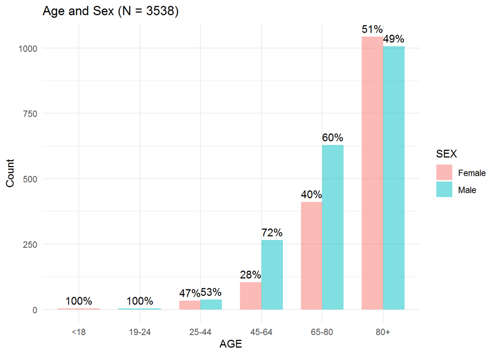

Figure 7.5: Distribution of Sex conditioned on Age.

```r
conditional_bar_plot(primary_enc,"AGE_BINNED","SEX_CD", "Age and Sex") +
  scale_fill_discrete(name = "SEX") +
  xlab("AGE")
```

Figure 7.6 shows the distribution of the length of stay (LOS) marked with the average LOS (**10.3** days). Encounters with either a missing admission or discharge date have been excluded.

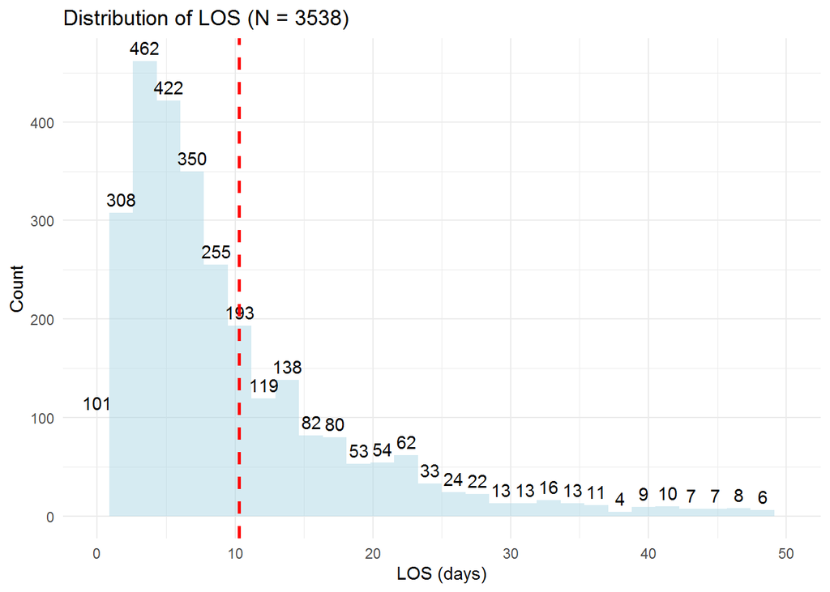

Figure 7.6: Distribution of Length of Stay

```r
plot_histogram(primary_enc,"LOS","Distribution of LOS",mean(primary_enc$LOS,na.rm=TRUE)) + xlab("LOS (days)") + xlim(0,50)
```

Figure 7.7 shows the distribution of encounters types.

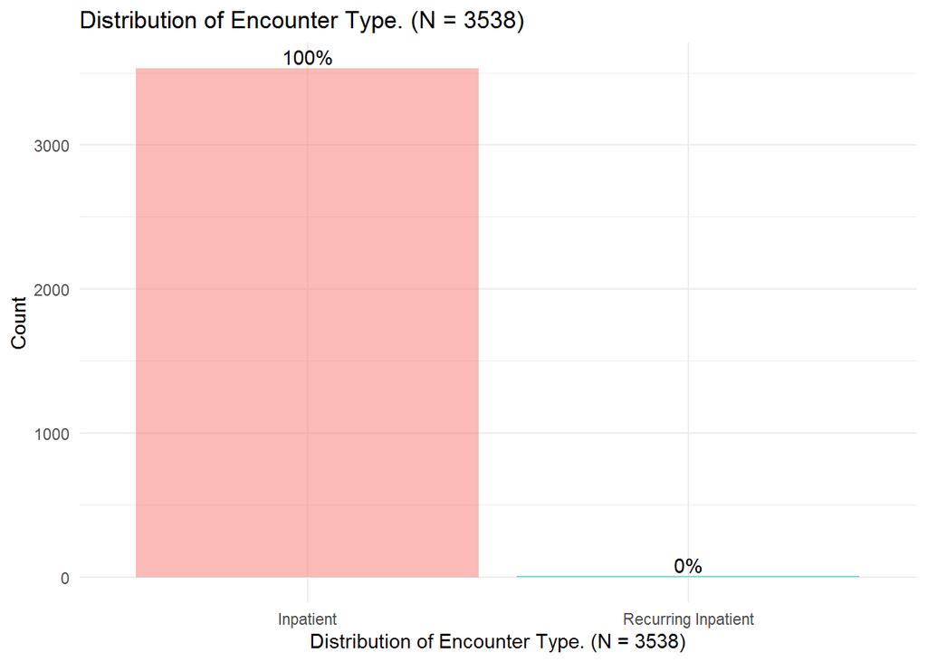

Figure 7.7: Distribution of Encounter Type.

```r
proportion_bar_plot(primary_enc,"ENCNTR_TYPE_CD","Distribution of Encounter Type.")
```

### 7.3.1 Advanced Care Directive

```r
known_to_hf <- problem %>%
  dplyr::filter(stringr::str_detect(SOURCE_STRING,"(?i)Known to heart failure")) %>%
  dplyr::select(PERSON_ID) %>%
  dplyr::mutate(HAS_ALERT = TRUE)

kk<- primary_cohort %>%
  merge(.,known_to_hf , by="PERSON_ID",all=TRUE) %>%
  replace(is.na(.), FALSE)

prop_tab <- prop.table(table(kk$HAS_PRIMARY_HF,kk$HAS_ALERT))
prop_tab %>%
  knitr::kable(caption = "Contigency table of Primary HF ICD10 and Advanced Care directive (ACD).",digits=2) %>%
  kableExtra::add_header_above(c("Has Primary\n ICD10"=1,"Has ACD"=2))%>%
  kable_styling(position = "center",full_width = FALSE)
```

Table 7.2: Contigency table of Primary HF ICD10 and Advanced Care directive (ACD).

| Has Primary ICD10 | Has ACD FALSE | Has ACD TRUE |
| --- | --- | --- |
| FALSE | 0.00 | 0.19 |
| TRUE | 0.57 | 0.24 |

### 7.3.2 Historical Diagnosis

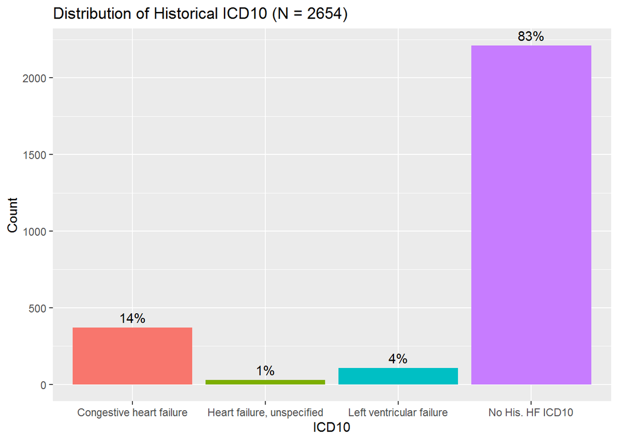

Figure 7.8: Distribution of historical diagnosis.

```r
his_hf_diag <- diagnosis_history %>%
  dplyr::filter(stringr::str_detect(SOURCE_IDENTIFIER,"(?i)I50") &
                  PERSON_ID %in% primary_cohort$PERSON_ID)

summary_his_diag <- his_hf_diag %>%
  extract_hf_diagnosis(group_cols = "PERSON_ID") %>%
  dplyr::right_join(primary_cohort,by="PERSON_ID") %>%
  dplyr::select(-HAS_PRIMARY_HF) %>%
  replace(is.na(.),FALSE) %>%
    dplyr::mutate(`No His. HF ICD10` = !`Congestive heart failure` & !`Heart failure, unspecified`
                  & !`Left ventricular failure`)
plot_logical_columns(summary_his_diag,"ICD10","Distribution of Historical ICD10")
```

### 7.3.3 Orders

```r
echos <- orders %>%
  dplyr::filter(stringr::str_detect(CATALOG_CD,"(?i)cardio - echo") & ENCNTR_ID %in% primary_enc$ENCNTR_ID) %>%
  dplyr::group_by(ENCNTR_ID) %>%
  dplyr::arrange(desc(STATUS_DT_TM)) %>%
  dplyr::slice(1) %>%
  dplyr::select(ENCNTR_ID,CATALOG_CD,STATUS_DT_TM) %>%
  dplyr::right_join(
    dplyr::select(primary_enc,ENCNTR_ID,ARRIVE_DT_TM),by="ENCNTR_ID") %>%
  dplyr::mutate(HAS_ECHO = !is.na(CATALOG_CD),ECHO_DELTA = difftime(STATUS_DT_TM,ARRIVE_DT_TM,units = "days")) %>%
  dplyr::ungroup() %>%
  dplyr::select(-CATALOG_CD) %>%
  dplyr::rename(ECHO_START_DT_TM = STATUS_DT_TM)
```

```r
path_tests <- execute_query("SELECT * from PATHOLOGY_EVENT where CATALOG_CD = 'Brain Natriuretic Peptide' or CATALOG_CD = 'Iron Level' or CATALOG_CD = 'Iron Studies' or CATALOG_CD = 'N Terminal Pro Brain Natriuretic Peptide'")

path_tests %<>%
  dplyr::filter(ENCNTR_ID %in% primary_enc$ENCNTR_ID) %>%
  dplyr::mutate(EVENT_CD = dplyr::case_when(
    stringr::str_detect(EVENT_CD,"(Brain Natriuretic peptide)|(N Terminal pro BNP)|(NT-ProBNP)") ~ "BNP",
    TRUE ~ EVENT_CD
  )) %>%
  dplyr::group_by(ENCNTR_ID,EVENT_CD) %>%
  dplyr::arrange(desc(EVENT_START_DT_TM)) %>%
  dplyr::slice(1) %>%
  dplyr::ungroup()
```

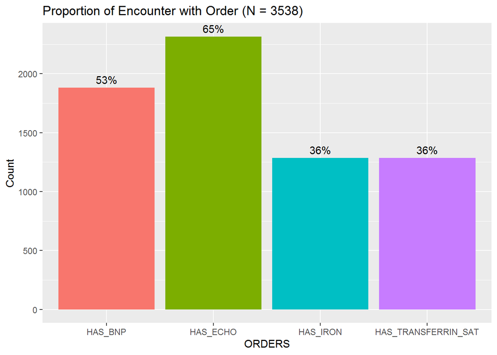

Figure 7.9: Number and proportion of Encounters with a relevant heart failure order, echocardiogram, brain natriuretic peptide test, serum iron test and transferrin saturation test.

```r
hf_order<-echos  %>%
  dplyr::left_join(
    extract_path_result(path_tests,"BNP", "BNP", c(-Inf,450,900,Inf),c("< 450","450-900","900+")), by="ENCNTR_ID"
  ) %>%
  dplyr::left_join(
    extract_path_result(path_tests,"Iron", "IRON",c(-Inf,9,30.4,Inf),c("< 9","9-30.4","30.4+")), by="ENCNTR_ID"
  ) %>%
  dplyr::left_join(
    extract_path_result(path_tests,"Transferrin Saturation", "TRANSFERRIN_SAT",c(-Inf,20,Inf),c("< 20","20+")), by="ENCNTR_ID"
  ) %>%
  dplyr::mutate(HAS_BNP = !is.na(BNP_EVENT_START_DT_TM),
                HAS_IRON = !is.na(IRON_EVENT_START_DT_TM),
                HAS_TRANSFERRIN_SAT = !is.na(TRANSFERRIN_SAT_EVENT_START_DT_TM))

plot_logical_columns(hf_order,"ORDERS","Proportion of Encounter with Order")
```

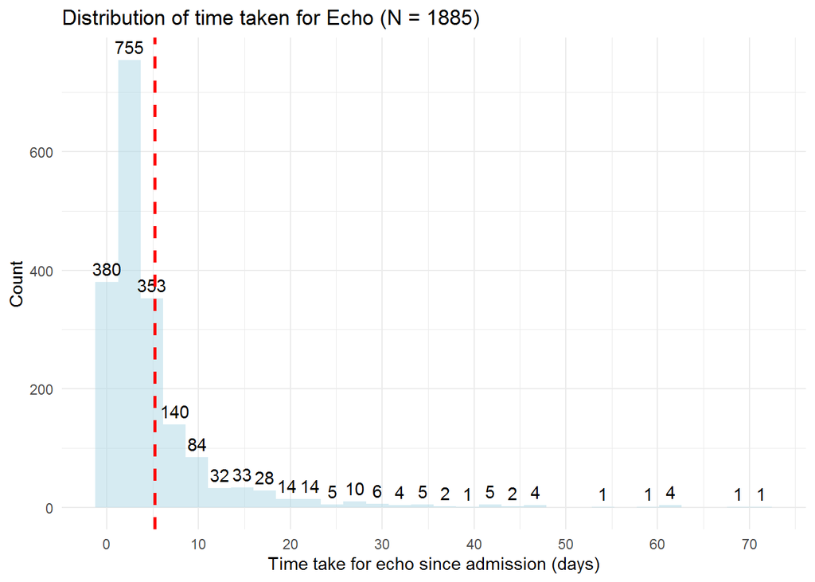

Figure 7.10: Distribution of the time taken for an echocardiogram.

```r
mean_delta <- mean(hf_order$ECHO_DELTA,na.rm = TRUE)
plot_histogram(hf_order %>% dplyr::filter(ECHO_DELTA < 75),
               "ECHO_DELTA","Distribution of time taken for Echo",
               mean_delta) +
    xlab("Time take for echo since admission (days)")
```

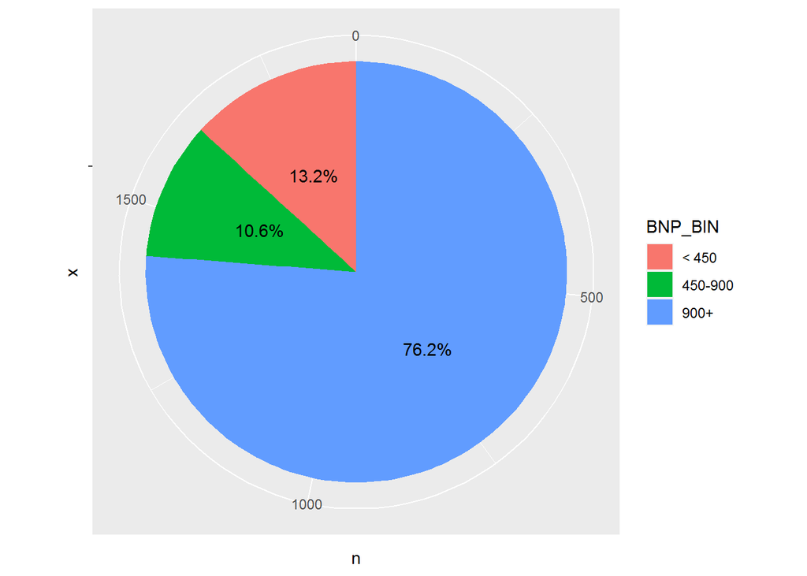

Figure 7.11: Results of pathology tests.

```r
p1<-plot_pie_chart(hf_order,"BNP_BIN","BNP Results by Group")
p2<-plot_pie_chart(hf_order,"IRON_BIN","BNP Results by Group")
p3<-plot_pie_chart(hf_order,"TRANSFERRIN_SAT_BIN","BNP Results by Group")

#ggpubr::ggarrange(p1,p2,p3,nrow=3,ncol=1,labels=c("A","B","C"))


p1
```

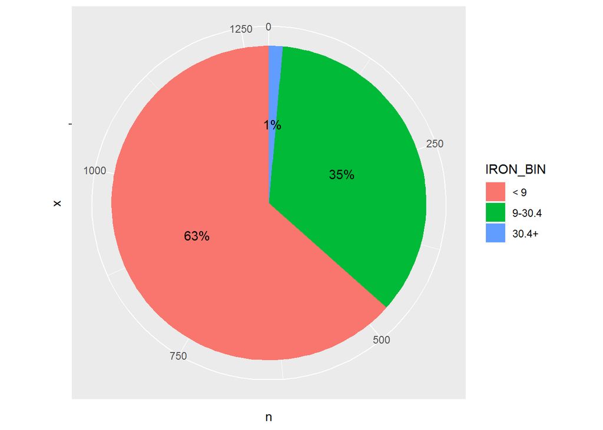

Figure 7.12: Results of pathology tests.

```r
p2
```

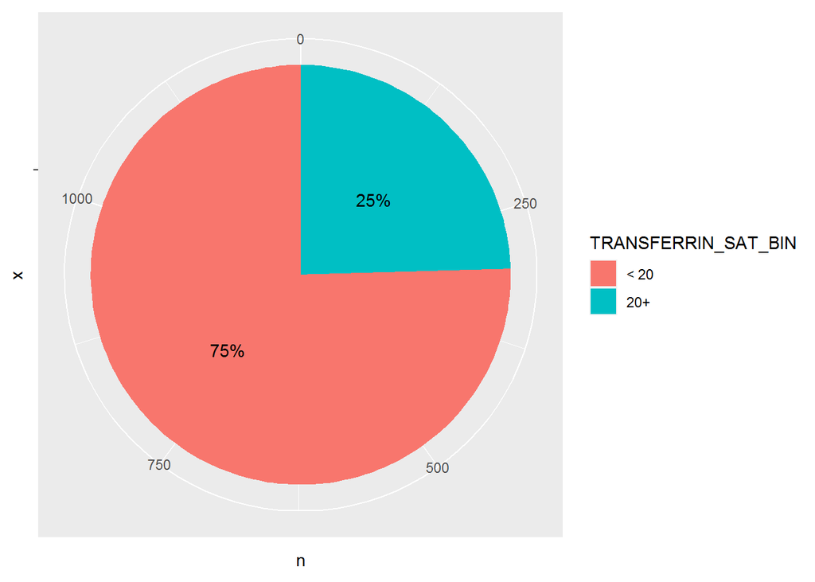

Figure 7.13: Results of pathology tests.

```r
p3
```

### 7.3.4 Forms

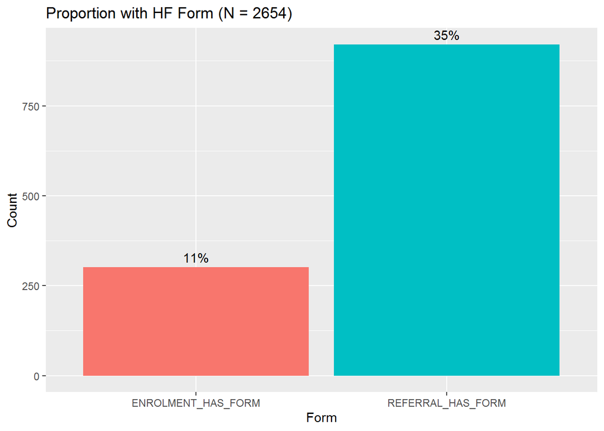

Figure 7.14: Proportion of Patients with an enrolment or referral form.

```r
form_primary_cohort <- primary_cohort %>%
  dplyr::left_join(
    extract_form(hf_form,'Heart Failure - Management of Cardiac Function Enrolment',"ENROLMENT"), by = c("PERSON_ID" = "ENROLMENT_PERSON_ID")
  ) %>%
  dplyr::left_join(
    extract_form(hf_form,'Heart Failure (MACARF) Referral Form',"REFERRAL"), by = c("PERSON_ID" = "REFERRAL_PERSON_ID")
  ) %>%
  tidyr::replace_na(list(ENROLMENT_HAS_FORM = FALSE, REFERRAL_HAS_FORM = FALSE))

plot_logical_columns(form_primary_cohort %>% dplyr::select(-HAS_PRIMARY_HF),"Form","Proportion with HF Form")
```